# 03. Fee狙いMM戦略バックテスト

## 目的

Order Imbalanceに基づくMaker Fee狙いのMM戦略をバックテストする。

## 戦略概要

1. Order Imbalanceを計算し、価格変動方向を予測
2. 予測方向にBest Bid/Askで指値注文を出す（Maker約定狙い）
3. 約定したらFee収益（2bps）を得る
4. ポジション管理でリスクを制限

```python
# 基本セットアップ
from etr.auto_import import *
HTML(full_width_display)
```

```python
# 追加ライブラリ
from etr.data.data_loader import load_data
from dataclasses import dataclass, field
from typing import List, Dict, Optional
import seaborn as sns
import warnings
warnings.filterwarnings('ignore')
```

## 1. データ読み込み

```python
# パラメータ設定
VENUE = 'bitbank'
SYM = 'XRPJPY'
DATE = '2026-01-25'

# Fee設定 (bps)
MAKER_FEE_BPS = -2  # 収益
TAKER_FEE_BPS = 12  # コスト

print(f"対象: {VENUE} {SYM}")
print(f"日付: {DATE}")
print(f"Maker Fee: {MAKER_FEE_BPS} bps, Taker Fee: {TAKER_FEE_BPS} bps")
```

```
対象: bitbank XRPJPY
日付: 2026-01-25
Maker Fee: -2 bps, Taker Fee: 12 bps
```

```python
# データ読み込み
book_df = load_data(DATE, 'MarketBook', VENUE, SYM)
trade_df = load_data(DATE, 'MarketTrade', VENUE, SYM)

print(f"MarketBook: {len(book_df):,} rows")
print(f"MarketTrade: {len(trade_df):,} rows")
```

```
2026-02-01 13:39:19.90 |INFO    |etr.data.data_loader: data_loader.load_data 95|Found 1 HDB files, process loading...
```

```
2026-02-01 13:39:20.868|INFO    |etr.data.data_loader: data_loader.load_data 95|Found 1 HDB files, process loading...
```

```
MarketBook: 244,469 rows
MarketTrade: 20,516 rows
```

```python
# 時間順にソート
book_df = book_df.sort_values('timestamp').reset_index(drop=True)
trade_df = trade_df.sort_values('timestamp').reset_index(drop=True)

# タイムスタンプをdatetime化
book_df['timestamp'] = pd.to_datetime(book_df['timestamp'])
trade_df['timestamp'] = pd.to_datetime(trade_df['timestamp'])
```

## 2. 板情報の特徴量抽出

```python
def extract_book_features(row, n_levels=5):
    """板情報から特徴量を抽出"""
    bids = row['bids']
    asks = row['asks']

    best_bid = bids[0][0] if len(bids) > 0 else np.nan
    best_ask = asks[0][0] if len(asks) > 0 else np.nan
    best_bid_size = bids[0][1] if len(bids) > 0 else 0
    best_ask_size = asks[0][1] if len(asks) > 0 else 0

    # n_levels分のボリューム
    bid_volumes = [bids[i][1] if i < len(bids) else 0 for i in range(n_levels)]
    ask_volumes = [asks[i][1] if i < len(asks) else 0 for i in range(n_levels)]

    total_bid_vol = sum(bid_volumes)
    total_ask_vol = sum(ask_volumes)

    # Order Imbalance
    imbalance = (total_bid_vol - total_ask_vol) / (total_bid_vol + total_ask_vol) if (total_bid_vol + total_ask_vol) > 0 else 0
    l1_imbalance = (best_bid_size - best_ask_size) / (best_bid_size + best_ask_size) if (best_bid_size + best_ask_size) > 0 else 0

    return {
        'timestamp': row['timestamp'],
        'best_bid': best_bid,
        'best_ask': best_ask,
        'best_bid_size': best_bid_size,
        'best_ask_size': best_ask_size,
        'imbalance': imbalance,
        'l1_imbalance': l1_imbalance
    }

# 特徴量抽出（サンプリングして高速化）
# 全データだと重いので100msごとにサンプリング
book_df_sampled = book_df.set_index('timestamp').resample('100ms').last().dropna(subset=['bids']).reset_index()
print(f"サンプリング後: {len(book_df_sampled):,} rows")

features = [extract_book_features(row) for _, row in book_df_sampled.iterrows()]
feat_df = pd.DataFrame(features)
print(f"特徴量抽出完了: {len(feat_df):,} rows")
```

```
サンプリング後: 243,224 rows
```

```
特徴量抽出完了: 243,224 rows
```

## 3. シンプルなMM戦略シミュレーション

### 戦略ロジック

1. Imbalance > threshold → 買い優勢 → Best Bidで買い指値
2. Imbalance < -threshold → 売り優勢 → Best Askで売り指値
3. 次の約定で自分の価格を通過したら約定とみなす
4. 約定後、一定時間で反対売買して決済

```python
@dataclass
class Order:
    """注文"""
    order_id: str
    timestamp: pd.Timestamp
    side: int  # 1: buy, -1: sell
    price: float
    size: float
    order_type: str = 'limit'
    status: str = 'new'  # new, filled, canceled
    filled_timestamp: Optional[pd.Timestamp] = None

@dataclass
class Trade:
    """約定"""
    trade_id: str
    order_id: str
    timestamp: pd.Timestamp
    side: int
    price: float
    size: float
    fee_bps: float

@dataclass
class MMStrategy:
    """Fee狙いMM戦略"""
    # パラメータ
    order_size: float = 100.0  # XRP
    imbalance_threshold: float = 0.3
    max_position: float = 500.0  # 最大ポジション
    position_timeout_sec: float = 30.0  # ポジション保持最大時間

    # 状態
    position: float = 0.0
    position_entry_time: Optional[pd.Timestamp] = None
    position_entry_price: float = 0.0
    active_order: Optional[Order] = None

    # 記録
    orders: List[Order] = field(default_factory=list)
    trades: List[Trade] = field(default_factory=list)

    # カウンター
    order_counter: int = 0
    trade_counter: int = 0

    def generate_signal(self, imbalance: float) -> int:
        """シグナル生成: 1=買い, -1=売り, 0=なし"""
        if imbalance > self.imbalance_threshold:
            return 1  # 買い
        elif imbalance < -self.imbalance_threshold:
            return -1  # 売り
        return 0

    def should_close_position(self, now: pd.Timestamp) -> bool:
        """ポジション決済判定"""
        if self.position == 0:
            return False
        if self.position_entry_time is None:
            return False
        elapsed = (now - self.position_entry_time).total_seconds()
        return elapsed > self.position_timeout_sec

    def place_order(self, timestamp: pd.Timestamp, side: int, price: float) -> Order:
        """注文発注"""
        self.order_counter += 1
        order = Order(
            order_id=f"ORD_{self.order_counter:06d}",
            timestamp=timestamp,
            side=side,
            price=price,
            size=self.order_size
        )
        self.orders.append(order)
        self.active_order = order
        return order

    def cancel_order(self):
        """注文キャンセル"""
        if self.active_order:
            self.active_order.status = 'canceled'
            self.active_order = None

    def fill_order(self, timestamp: pd.Timestamp, is_maker: bool = True):
        """注文約定"""
        if self.active_order is None:
            return

        order = self.active_order
        order.status = 'filled'
        order.filled_timestamp = timestamp

        self.trade_counter += 1
        fee_bps = MAKER_FEE_BPS if is_maker else TAKER_FEE_BPS

        trade = Trade(
            trade_id=f"TRD_{self.trade_counter:06d}",
            order_id=order.order_id,
            timestamp=timestamp,
            side=order.side,
            price=order.price,
            size=order.size,
            fee_bps=fee_bps
        )
        self.trades.append(trade)

        # ポジション更新
        prev_position = self.position
        self.position += order.side * order.size

        # エントリー時刻記録
        if prev_position == 0 and self.position != 0:
            self.position_entry_time = timestamp
            self.position_entry_price = order.price
        elif self.position == 0:
            self.position_entry_time = None
            self.position_entry_price = 0

        self.active_order = None

    def check_fill(self, market_trade_price: float, market_trade_side: int) -> bool:
        """約定判定: 市場約定が自分の注文価格を通過したか"""
        if self.active_order is None:
            return False

        order = self.active_order

        # 買い指値: 市場の売りが自分の買い価格以下で約定
        if order.side == 1 and market_trade_side == -1:
            if market_trade_price <= order.price:
                return True

        # 売り指値: 市場の買いが自分の売り価格以上で約定
        if order.side == -1 and market_trade_side == 1:
            if market_trade_price >= order.price:
                return True

        return False
```

```python
def run_backtest(feat_df: pd.DataFrame, trade_df: pd.DataFrame,
                 imbalance_threshold: float = 0.3,
                 order_size: float = 100.0,
                 position_timeout_sec: float = 30.0) -> MMStrategy:
    """バックテスト実行"""

    strategy = MMStrategy(
        order_size=order_size,
        imbalance_threshold=imbalance_threshold,
        position_timeout_sec=position_timeout_sec
    )

    # イベントを時間順に結合
    book_events = [(row['timestamp'], 'book', row) for _, row in feat_df.iterrows()]
    trade_events = [(row['timestamp'], 'trade', row) for _, row in trade_df.iterrows()]

    all_events = sorted(book_events + trade_events, key=lambda x: x[0])

    current_book = None

    for timestamp, event_type, data in all_events:

        if event_type == 'book':
            current_book = data

            # ポジションタイムアウトチェック
            if strategy.should_close_position(timestamp):
                # 強制決済（Taker）
                if strategy.position > 0:
                    # ロング決済 → 売り
                    strategy.cancel_order()
                    strategy.place_order(timestamp, -1, data['best_bid'])
                    strategy.fill_order(timestamp, is_maker=False)  # Taker
                elif strategy.position < 0:
                    # ショート決済 → 買い
                    strategy.cancel_order()
                    strategy.place_order(timestamp, 1, data['best_ask'])
                    strategy.fill_order(timestamp, is_maker=False)  # Taker

            # 新規注文判定
            if strategy.active_order is None and abs(strategy.position) < strategy.max_position:
                signal = strategy.generate_signal(data['imbalance'])

                if signal == 1:  # 買いシグナル
                    strategy.place_order(timestamp, 1, data['best_bid'])
                elif signal == -1:  # 売りシグナル
                    strategy.place_order(timestamp, -1, data['best_ask'])

        elif event_type == 'trade':
            # 約定判定
            # sideが数値の場合とstr場合を処理
            trade_side = data['side']
            if isinstance(trade_side, str):
                trade_side = 1 if trade_side == 'buy' else -1

            if strategy.check_fill(data['price'], trade_side):
                strategy.fill_order(timestamp, is_maker=True)

    return strategy
```

```python
%%time
# バックテスト実行
strategy = run_backtest(
    feat_df,
    trade_df,
    imbalance_threshold=0.3,
    order_size=100.0,
    position_timeout_sec=30.0
)

print(f"\n=== 結果 ===")
print(f"総注文数: {len(strategy.orders):,}")
print(f"総約定数: {len(strategy.trades):,}")
print(f"最終ポジション: {strategy.position:.2f}")
```

```
=== 結果 ===
総注文数: 70
総約定数: 46
最終ポジション: 0.00
CPU times: user 6.6 s, sys: 161 ms, total: 6.76 s
Wall time: 6.76 s
```

## 4. 結果分析

```python
# 約定をDataFrameに変換
if strategy.trades:
    trades_result = pd.DataFrame([
        {
            'timestamp': t.timestamp,
            'side': t.side,
            'price': t.price,
            'size': t.size,
            'fee_bps': t.fee_bps,
            'notional': t.price * t.size,
            'fee_jpy': t.price * t.size * t.fee_bps / 10000
        }
        for t in strategy.trades
    ])

    print("約定サマリー:")
    print(f"  総約定数: {len(trades_result):,}")
    print(f"  Maker約定: {(trades_result['fee_bps'] == MAKER_FEE_BPS).sum():,}")
    print(f"  Taker約定: {(trades_result['fee_bps'] == TAKER_FEE_BPS).sum():,}")
    print(f"  総約定額: ¥{trades_result['notional'].sum():,.0f}")
    print(f"  Fee収益: ¥{-trades_result['fee_jpy'].sum():,.0f}")  # マイナスなので反転

    display(trades_result.head(10))
else:
    print("約定なし")
```

```
約定サマリー:
  総約定数: 46
  Maker約定: 23
  Taker約定: 23
  総約定額: ¥1,373,178
  Fee収益: ¥-687
```

|  | timestamp | side | price | size | fee_bps | notional | fee_jpy |
| --- | --- | --- | --- | --- | --- | --- | --- |
| 0 | 2026-01-25 00:03:23.017113+00:00 | -1 | 298.616 | 100.0 | -2 | 29861.6 | -5.97232 |
| 1 | 2026-01-25 00:03:53.300000+00:00 | 1 | 298.658 | 100.0 | 12 | 29865.8 | 35.83896 |
| 2 | 2026-01-25 00:10:50.573578+00:00 | 1 | 298.657 | 100.0 | -2 | 29865.7 | -5.97314 |
| 3 | 2026-01-25 00:11:20.800000+00:00 | -1 | 298.586 | 100.0 | 12 | 29858.6 | 35.83032 |
| 4 | 2026-01-25 00:11:33.618230+00:00 | -1 | 298.587 | 100.0 | -2 | 29858.7 | -5.97174 |
| 5 | 2026-01-25 00:12:04+00:00 | 1 | 298.587 | 100.0 | 12 | 29858.7 | 35.83044 |
| 6 | 2026-01-25 00:14:22.838801+00:00 | -1 | 298.587 | 100.0 | -2 | 29858.7 | -5.97174 |
| 7 | 2026-01-25 00:14:52.900000+00:00 | 1 | 298.587 | 100.0 | 12 | 29858.7 | 35.83044 |
| 8 | 2026-01-25 00:14:56.872486+00:00 | -1 | 298.587 | 100.0 | -2 | 29858.7 | -5.97174 |
| 9 | 2026-01-25 00:15:19.902488+00:00 | -1 | 298.587 | 100.0 | -2 | 29858.7 | -5.97174 |

```python
# ラウンドトリップ（往復）のP&L計算
if len(trades_result) >= 2:
    trades_result['position'] = (trades_result['side'] * trades_result['size']).cumsum()

    # ポジションがゼロになったポイントでラウンドトリップを区切る
    trades_result['is_flat'] = trades_result['position'] == 0
    trades_result['round_trip_id'] = trades_result['is_flat'].shift(1, fill_value=True).cumsum()

    # ラウンドトリップごとのP&L
    def calc_round_trip_pnl(group):
        if len(group) < 2:
            return pd.Series({'pnl_price': np.nan, 'pnl_fee': np.nan, 'pnl_total': np.nan})

        # 価格損益
        entry = group.iloc[0]
        exit_ = group.iloc[-1]

        if entry['side'] == 1:  # 買いエントリー
            pnl_price = (exit_['price'] - entry['price']) * entry['size']
        else:  # 売りエントリー
            pnl_price = (entry['price'] - exit_['price']) * entry['size']

        # Fee損益（マイナスが収益）
        pnl_fee = -group['fee_jpy'].sum()

        return pd.Series({
            'entry_time': entry['timestamp'],
            'exit_time': exit_['timestamp'],
            'entry_side': entry['side'],
            'entry_price': entry['price'],
            'exit_price': exit_['price'],
            'size': entry['size'],
            'pnl_price': pnl_price,
            'pnl_fee': pnl_fee,
            'pnl_total': pnl_price + pnl_fee,
            'maker_count': (group['fee_bps'] == MAKER_FEE_BPS).sum(),
            'taker_count': (group['fee_bps'] == TAKER_FEE_BPS).sum()
        })

    round_trips = trades_result.groupby('round_trip_id').apply(calc_round_trip_pnl).dropna()

    if len(round_trips) > 0:
        print(f"\n=== ラウンドトリップ分析 ===")
        print(f"総ラウンドトリップ数: {len(round_trips):,}")
        print(f"価格損益合計: ¥{round_trips['pnl_price'].sum():,.0f}")
        print(f"Fee収益合計: ¥{round_trips['pnl_fee'].sum():,.0f}")
        print(f"総合損益: ¥{round_trips['pnl_total'].sum():,.0f}")
        print(f"勝率: {(round_trips['pnl_total'] > 0).mean() * 100:.1f}%")
        print(f"平均損益: ¥{round_trips['pnl_total'].mean():,.2f}")

        display(round_trips.head(20))
```

```
=== ラウンドトリップ分析 ===
総ラウンドトリップ数: 15
価格損益合計: ¥-7
Fee収益合計: ¥-687
総合損益: ¥-694
勝率: 0.0%
平均損益: ¥-46.24
```

| round_trip_id | entry_time | exit_time | entry_side | entry_price | exit_price | size | pnl_price | pnl_fee | pnl_total | maker_count | taker_count |
| --- | --- | --- | --- | --- | --- | --- | --- | --- | --- | --- | --- |
| 1 | 2026-01-25 00:03:23.017113+00:00 | 2026-01-25 00:03:53.300000+00:00 | -1 | 298.616 | 298.658 | 100.0 | -4.2 | -29.86664 | -34.06664 | 1 | 1 |
| 2 | 2026-01-25 00:10:50.573578+00:00 | 2026-01-25 00:11:20.800000+00:00 | 1 | 298.657 | 298.586 | 100.0 | -7.1 | -29.85718 | -36.95718 | 1 | 1 |
| 3 | 2026-01-25 00:11:33.618230+00:00 | 2026-01-25 00:12:04+00:00 | -1 | 298.587 | 298.587 | 100.0 | 0.0 | -29.85870 | -29.85870 | 1 | 1 |
| 4 | 2026-01-25 00:14:22.838801+00:00 | 2026-01-25 00:14:52.900000+00:00 | -1 | 298.587 | 298.587 | 100.0 | 0.0 | -29.85870 | -29.85870 | 1 | 1 |
| 5 | 2026-01-25 00:14:56.872486+00:00 | 2026-01-25 00:15:27.700000+00:00 | -1 | 298.587 | 298.587 | 100.0 | 0.0 | -59.71740 | -59.71740 | 2 | 2 |
| 6 | 2026-01-25 00:15:50.973856+00:00 | 2026-01-25 00:16:21.500000+00:00 | -1 | 298.587 | 298.502 | 100.0 | 8.5 | -59.69700 | -51.19700 | 2 | 2 |
| 7 | 2026-01-25 00:17:09.027208+00:00 | 2026-01-25 00:17:39.100000+00:00 | -1 | 298.502 | 298.502 | 100.0 | 0.0 | -29.85020 | -29.85020 | 1 | 1 |
| 8 | 2026-01-25 00:20:13.265887+00:00 | 2026-01-25 00:20:43.500000+00:00 | -1 | 298.502 | 298.621 | 100.0 | -11.9 | -29.86448 | -41.76448 | 1 | 1 |
| 9 | 2026-01-25 00:22:19.446155+00:00 | 2026-01-25 00:22:49.500000+00:00 | 1 | 298.620 | 298.584 | 100.0 | -3.6 | -29.85768 | -33.45768 | 1 | 1 |
| 10 | 2026-01-25 01:01:33.259871+00:00 | 2026-01-25 01:02:03.400000+00:00 | -1 | 298.585 | 298.491 | 100.0 | 9.4 | -29.84722 | -20.44722 | 1 | 1 |
| 11 | 2026-01-25 01:02:21.308571+00:00 | 2026-01-25 01:02:52.200000+00:00 | -1 | 298.491 | 298.418 | 100.0 | 7.3 | -89.52102 | -82.22102 | 3 | 3 |
| 12 | 2026-01-25 01:02:54.361809+00:00 | 2026-01-25 01:03:24.800000+00:00 | -1 | 298.418 | 298.418 | 100.0 | 0.0 | -59.68360 | -59.68360 | 2 | 2 |
| 13 | 2026-01-25 01:03:25.370721+00:00 | 2026-01-25 01:03:55.400000+00:00 | -1 | 298.418 | 298.457 | 100.0 | -3.9 | -29.84648 | -33.74648 | 1 | 1 |
| 14 | 2026-01-25 01:04:41.462515+00:00 | 2026-01-25 01:05:12.300000+00:00 | -1 | 298.457 | 298.472 | 100.0 | -1.5 | -89.54190 | -91.04190 | 3 | 3 |
| 15 | 2026-01-25 01:05:14.509131+00:00 | 2026-01-25 01:05:44.900000+00:00 | -1 | 298.472 | 298.472 | 100.0 | 0.0 | -59.69440 | -59.69440 | 2 | 2 |

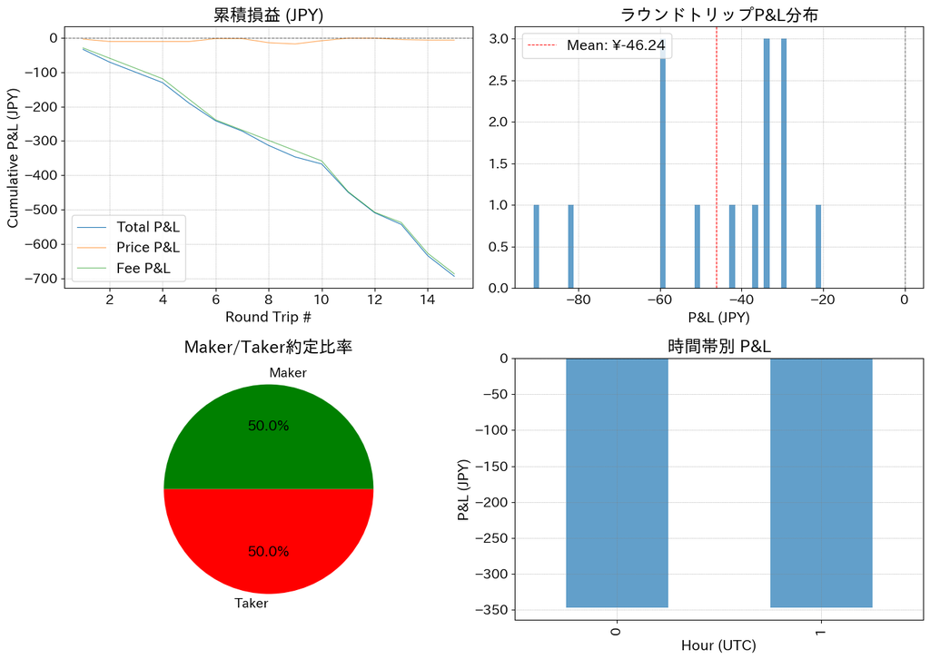

```python
# 累積損益の可視化
if len(round_trips) > 0:
    fig, axes = plt.subplots(2, 2, figsize=(14, 10))

    # 累積P&L
    round_trips['cum_pnl_total'] = round_trips['pnl_total'].cumsum()
    round_trips['cum_pnl_price'] = round_trips['pnl_price'].cumsum()
    round_trips['cum_pnl_fee'] = round_trips['pnl_fee'].cumsum()

    axes[0, 0].plot(round_trips['cum_pnl_total'], label='Total P&L')
    axes[0, 0].plot(round_trips['cum_pnl_price'], label='Price P&L', alpha=0.7)
    axes[0, 0].plot(round_trips['cum_pnl_fee'], label='Fee P&L', alpha=0.7)
    axes[0, 0].set_title('累積損益 (JPY)')
    axes[0, 0].set_xlabel('Round Trip #')
    axes[0, 0].set_ylabel('Cumulative P&L (JPY)')
    axes[0, 0].legend()
    axes[0, 0].axhline(y=0, color='black', linestyle='--', alpha=0.5)

    # P&L分布
    round_trips['pnl_total'].hist(bins=50, ax=axes[0, 1], alpha=0.7)
    axes[0, 1].axvline(x=0, color='black', linestyle='--', alpha=0.5)
    axes[0, 1].axvline(x=round_trips['pnl_total'].mean(), color='red', linestyle='--', label=f"Mean: ¥{round_trips['pnl_total'].mean():.2f}")
    axes[0, 1].set_title('ラウンドトリップP&L分布')
    axes[0, 1].set_xlabel('P&L (JPY)')
    axes[0, 1].legend()

    # Maker/Taker比率
    maker_total = round_trips['maker_count'].sum()
    taker_total = round_trips['taker_count'].sum()
    axes[1, 0].pie([maker_total, taker_total], labels=['Maker', 'Taker'], autopct='%1.1f%%', colors=['green', 'red'])
    axes[1, 0].set_title('Maker/Taker約定比率')

    # 時間帯別パフォーマンス
    round_trips['hour'] = pd.to_datetime(round_trips['entry_time']).dt.hour
    hourly_pnl = round_trips.groupby('hour')['pnl_total'].sum()
    hourly_pnl.plot(kind='bar', ax=axes[1, 1], alpha=0.7)
    axes[1, 1].set_title('時間帯別 P&L')
    axes[1, 1].set_xlabel('Hour (UTC)')
    axes[1, 1].set_ylabel('P&L (JPY)')
    axes[1, 1].axhline(y=0, color='black', linestyle='--', alpha=0.5)

    plt.tight_layout()
    plt.show()
```

## 5. パラメータ感度分析

```python
# 閾値を変えてパフォーマンスを比較
thresholds = [0.1, 0.2, 0.3, 0.4, 0.5]
timeouts = [10, 30, 60]

param_results = []

for thresh in thresholds:
    for timeout in timeouts:
        strat = run_backtest(
            feat_df,
            trade_df,
            imbalance_threshold=thresh,
            order_size=100.0,
            position_timeout_sec=timeout
        )

        if strat.trades:
            tr = pd.DataFrame([{
                'side': t.side, 'price': t.price, 'size': t.size, 'fee_bps': t.fee_bps
            } for t in strat.trades])

            tr['notional'] = tr['price'] * tr['size']
            tr['fee_jpy'] = tr['notional'] * tr['fee_bps'] / 10000

            total_fee_pnl = -tr['fee_jpy'].sum()
            maker_ratio = (tr['fee_bps'] == MAKER_FEE_BPS).mean()

            param_results.append({
                'threshold': thresh,
                'timeout': timeout,
                'trade_count': len(tr),
                'maker_ratio': maker_ratio,
                'fee_pnl': total_fee_pnl,
                'notional': tr['notional'].sum()
            })

param_df = pd.DataFrame(param_results)
print("パラメータ感度分析:")
display(param_df.round(2))
```

```
パラメータ感度分析:
```

|  | threshold | timeout | trade_count | maker_ratio | fee_pnl | notional |
| --- | --- | --- | --- | --- | --- | --- |
| 0 | 0.1 | 10 | 24 | 0.50 | -358.30 | 716607.8 |
| 1 | 0.1 | 30 | 46 | 0.50 | -686.56 | 1373177.7 |
| 2 | 0.1 | 60 | 90 | 0.50 | -1342.97 | 2685931.3 |
| 3 | 0.2 | 10 | 52 | 0.52 | -734.36 | 1552307.2 |
| 4 | 0.2 | 30 | 46 | 0.50 | -686.56 | 1373177.7 |
| 5 | 0.2 | 60 | 90 | 0.50 | -1342.97 | 2685931.3 |
| 6 | 0.3 | 10 | 12 | 0.50 | -179.24 | 358463.5 |
| 7 | 0.3 | 30 | 46 | 0.50 | -686.56 | 1373177.7 |
| 8 | 0.3 | 60 | 68 | 0.51 | -973.12 | 2029919.4 |
| 9 | 0.4 | 10 | 12 | 0.50 | -179.24 | 358463.5 |
| 10 | 0.4 | 30 | 48 | 0.52 | -674.62 | 1432902.0 |
| 11 | 0.4 | 60 | 36 | 0.53 | -495.54 | 1074717.8 |
| 12 | 0.5 | 10 | 12 | 0.50 | -179.24 | 358463.5 |
| 13 | 0.5 | 30 | 48 | 0.52 | -674.62 | 1432902.0 |
| 14 | 0.5 | 60 | 36 | 0.53 | -495.54 | 1074717.8 |

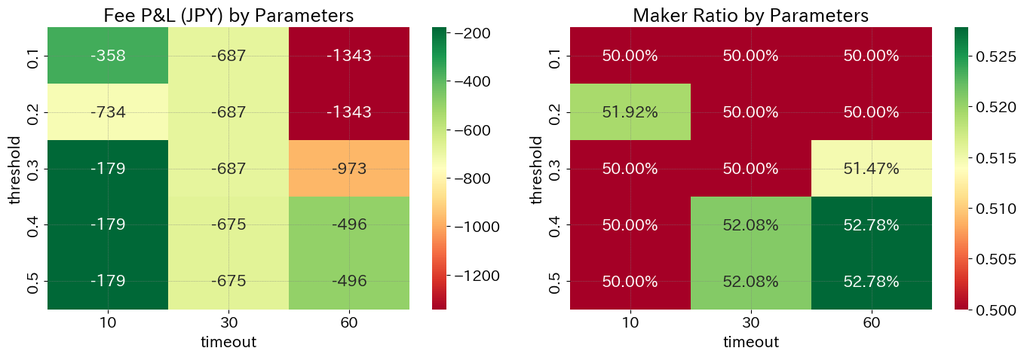

```python
# ヒートマップで可視化
if len(param_df) > 0:
    fig, axes = plt.subplots(1, 2, figsize=(14, 5))

    # Fee P&Lのヒートマップ
    pivot_pnl = param_df.pivot(index='threshold', columns='timeout', values='fee_pnl')
    sns.heatmap(pivot_pnl, annot=True, fmt='.0f', cmap='RdYlGn', ax=axes[0])
    axes[0].set_title('Fee P&L (JPY) by Parameters')

    # Maker比率のヒートマップ
    pivot_maker = param_df.pivot(index='threshold', columns='timeout', values='maker_ratio')
    sns.heatmap(pivot_maker, annot=True, fmt='.2%', cmap='RdYlGn', ax=axes[1])
    axes[1].set_title('Maker Ratio by Parameters')

    plt.tight_layout()
    plt.show()
```

## 6. まとめ

### 課題

1. ポジションタイムアウト時のTaker約定コストが大きい
2. 価格変動リスクの管理が必要
3. より洗練されたシグナル・発注ロジックの検討

### 次のステップ

1. 複数日でのバックテスト
2. BTCJPYでの検証
3. ストップロス・テイクプロフィットの導入
4. 他取引所の価格を使った予測の追加